# CS2013-16 qt_trend

Kang Sung Won

2017 4 24

Preliminary analysis on 2013-16 consumer survey.

1. preperation

```r
#d=read.csv(file="CS2016/CS2016.txt",header=F,as.is=T)
#save(d,file="CS2016/CS2016p.rdata")
#load("CS2016/CS2016p.rdata")
#vname=read.csv(file="CS2016/vlist.csv",header=T,as.is=T)
#colnames(d)=vname$Ename
#d2016=d

#d2015=read.csv(file="CS2015/CS2015.txt",header=F,as.is=T)
vname2015=read.csv(file="CS2015/vlist2015.csv",header=T,as.is=T)
#colnames(d2015)=vname2015$Ename
#save(d2015,file="CS2015/CS2015p.rdata")

#d2014=read.csv(file="CS2014/CS2014.txt",header=F,as.is=T)
#vname2014=read.csv(file="CS2014/vlist2014.csv",header=T,as.is=T)
#colnames(d2014)=vname2014$Ename
#save(d2014,file="CS2014/CS2014p.rdata")

#d2013=read.csv(file="CS2013/CS2013.txt",header=F,as.is=T)
#vname2013=read.csv(file="CS2013/vlist2013.csv",header=T,as.is=T)
#colnames(d2013)=vname2013$Ename
#save(d2013,file="CS2013/CS2013p.rdata")
#colnames(d2014)[2]="quarter"
#colnames(d2013)[2]="quarter"
#save(d2014,file="CS2014/CS2014p.rdata")
#save(d2013,file="CS2013/CS2013p.rdata")
load("dCSp.rdata")
#dCS=rbind(d2016,d2015,d2014,d2013)
#save(dCS,file="dCSp.rdata")
```

2. calculate Average propensity of consumption. Each expenditure item.

Expenditure items are as follows.

```r
vname2015[134:258,]
```

```
##     index category                      kname begin length
## 134   134     숫자                   가계지출   505     10
## 135   135     숫자                   소비지출   515     10
## 136   136     숫자      01.식료품및비주류음료   525     10
## 137   137     숫자                       곡물   535     10
## 138   138     숫자                 곡물가공품   545     10
## 139   139     숫자                   빵및떡류   555     10
## 140   140     숫자                       육류   565     10
## 141   141     숫자                 육류가공품   575     10
## 142   142     숫자               신선수산동물   585     10
## 143   143     숫자               염건수산동물   595     10
## 144   144     숫자           기타수산동물가공   605     10
## 145   145     숫자                 유제품및알   615     10
## 146   146     숫자                     유지류   625     10
## 147   147     숫자           과일및과일가공품   635     10
```

[output cut: 237 more lines]

We get Eshare = Expenditure item of Econ/Econ

Then we obtain quater mean of APC.

```r
library(dplyr)
```

```r
library(tidyr)
library(ggplot2)
```

First, we look on BandB. The BandB expenditure share in consumption in 2016 fourth quarter was consistent with those of previous 3 years. The ‘hotel’ expenditure share was actually highest in 2016.

```r
Eshare[,c(1:2,260:371)] %>% group_by(year,quarter) %>% summarize_all(mean) %>% select(1:2,102:104) %>% filter(quarter==44)
```

```
## Source: local data frame [4 x 5]
## Groups: year [4]
##
##    year quarter  R_EBandB R_EBandB_eat R_EBandB_hotel
##   <int>   <int>     <dbl>        <dbl>          <dbl>
## 1  2013      44 0.1266964    0.1251176    0.001578782
## 2  2014      44 0.1292508    0.1272491    0.002001674
## 3  2015      44 0.1280390    0.1261803    0.001858665
## 4  2016      44 0.1286690    0.1263787    0.002290287
```

Second, we look on Food expenditure. We found 4 items had loweset 4th quarter consumption expenditure share in 2016 in 2013-16: Raw fish (R_EF_fish_raw), raw grain (R_EF_grain_raw), source (R_EF_source), tea (R_EF_tea). Among them, the raw fish might have affected by clean act. But the 2016 4th quarter raw fish consumption expenditure ratio is in line with previous observations. If we check the mean deviation, we can see that the 2016 fourth quarter drop of raw fish share only represents the low annual average.

```r
Eshare[,c(1:2,260:371)] %>% group_by(year,quarter) %>% summarize_all(mean) %>% select(1:2,4:25)%>% filter(quarter==44)
```

```
## Source: local data frame [4 x 24]
## Groups: year [4]
##
##    year quarter      R_EF R_EF_grain_raw R_EF_grain_adj   R_EF_cake
##   <int>   <int>     <dbl>          <dbl>          <dbl>       <dbl>
## 1  2013      44 0.1865072     0.02403731    0.008135664 0.008951003
## 2  2014      44 0.1840770     0.02227799    0.007756294 0.008932160
## 3  2015      44 0.1826627     0.02004513    0.008030050 0.008937918
## 4  2016      44 0.1881131     0.01622312    0.008018730 0.009259105
## # ... with 18 more variables: R_EF_meat <dbl>, R_EF_meat_adj <dbl>,
## #   R_EF_fish_raw <dbl>, R_EF_fish_dry <dbl>, R_EF_fish_etc <dbl>,
## #   R_EF_dairy <dbl>, R_EF_oil <dbl>, R_EF_fruit <dbl>, R_EF_vegi <dbl>,
## #   R_EF_seeweed <dbl>, R_EF_candy <dbl>, R_EF_source <dbl>,
## #   R_EF_etc <dbl>, R_EF_tea <dbl>, R_EF_drink <dbl>, R_EBT <dbl>,
## #   R_EBT_booj <dbl>, R_EBT_taba <dbl>
```

```r
Eshare[,c(1:2,260:371)] %>% group_by(year,quarter) %>% summarize_all(mean) %>% select(1:2,4:25) %>% filter(quarter==44)%>%gather(Vname,Value,-(1:2)) %>% ungroup() %>% group_by(Vname) %>% summarize_at(-(1:2),which.min) %>%filter(Value==4)
```

```
## # A tibble: 4 × 2
##            Vname Value
##            <chr> <int>
## 1  R_EF_fish_raw     4
## 2 R_EF_grain_raw     4
## 3    R_EF_source     4
## 4       R_EF_tea     4
```

```r
Eshare[,c(1:2,260:371)] %>% group_by(year,quarter) %>% summarize_all(mean) %>% select(1:2,4:25) %>% filter(quarter==44)%>%select(year, quarter, R_EF_fish_raw)
```

```
## Source: local data frame [4 x 3]
## Groups: year [4]
##
##    year quarter R_EF_fish_raw
##   <int>   <int>         <dbl>
## 1  2013      44    0.01338314
## 2  2014      44    0.01340760
## 3  2015      44    0.01380346
## 4  2016      44    0.01323144
```

```r
dmean=function(x){x-mean(x)}

Eshare[,c(1:2,260:371)] %>% group_by(year,quarter) %>% summarize_all(mean) %>% select(1:2,4:25) %>% mutate_at(-(1:2),dmean) %>% filter(quarter==44) %>% select(year, quarter, R_EF_fish_raw)
```

```
## Source: local data frame [4 x 3]
## Groups: year [4]
##
##    year quarter R_EF_fish_raw
##   <int>   <int>         <dbl>
## 1  2013      44 -0.0001148252
## 2  2014      44 -0.0002144687
## 3  2015      44  0.0001421287
## 4  2016      44 -0.0001445032
```

```r
#,Value,-(1:2)) %>% filter(Vname=="R_EF_ungroup() %>% group_by(Vname) %>% summarize_at(-(1:2),which.min) %>%filter(Value==4)

#Eshare[,c(1:2,260:371)] %>% group_by(year,quarter) %>% summarize_all(mean) %>% select(1:2,101:103)
```

We can confirm that there was not much of drop in 4th quarter consumption by looking at the graph.

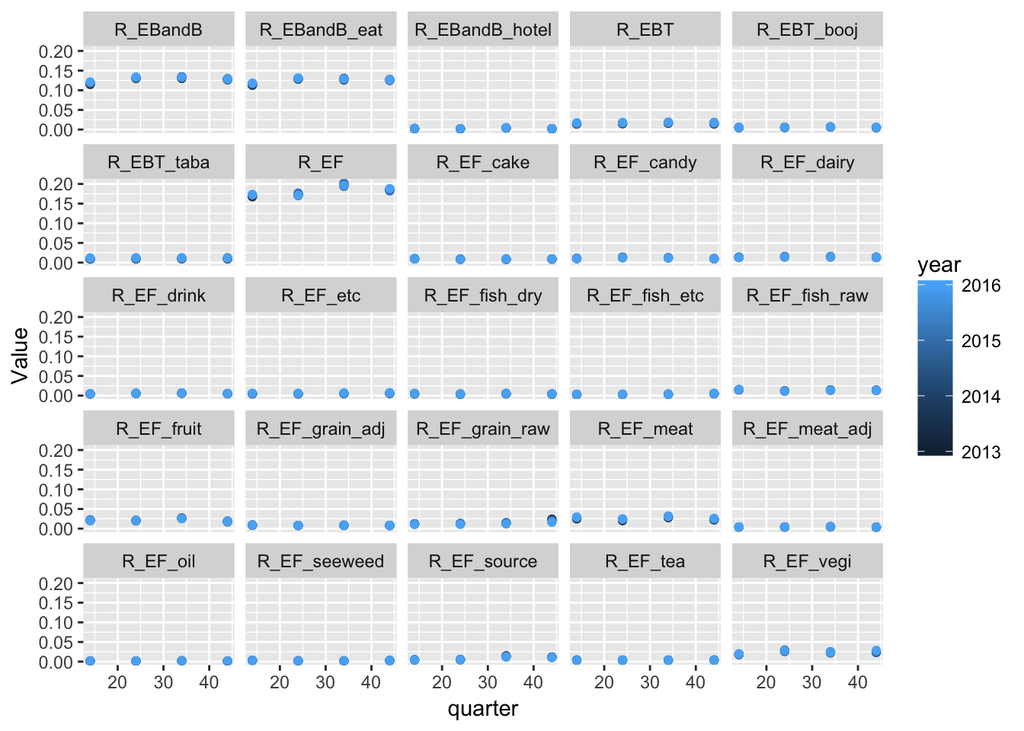

```r
Eshare[,c(1:2,260:371)] %>% group_by(year,quarter) %>% summarize_all(mean) %>% select(1:2,4:25,102:104) %>% gather(Vname,Value,3:27) %>%ggplot(aes(x=quarter, y=Value,color=year))+geom_point()+facet_wrap(~Vname)
```

We also check consumption share deviation from annual mean in 4th quarter from 2013 to 2016. Except for raw grain, no items showed that the 2016 4th quater consumption share was particularly lower than annual average compared in 2016.

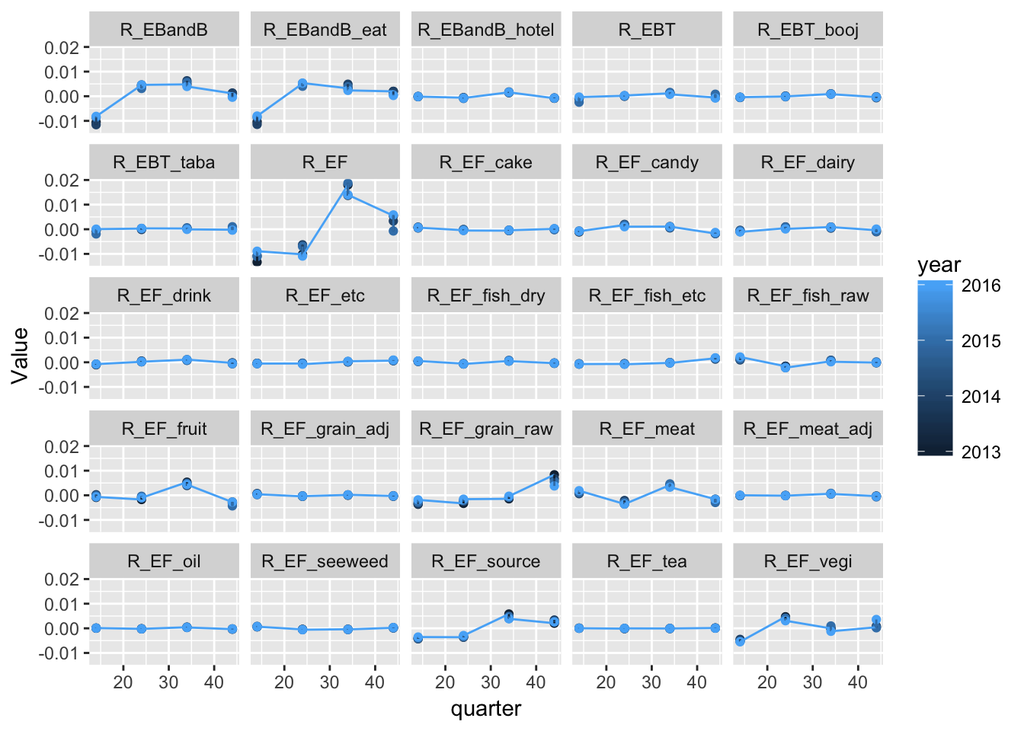

```r
Eshare[,c(1:2,260:371)] %>% group_by(year,quarter) %>% summarize_all(mean) %>% select(1:2,4:25,102:104) %>% mutate_at(-(1:2),dmean) %>% gather(Vname,Value,3:27) %>%ggplot(aes(x=quarter, y=Value,color=year))+geom_point()+geom_line()+facet_wrap(~Vname)
```

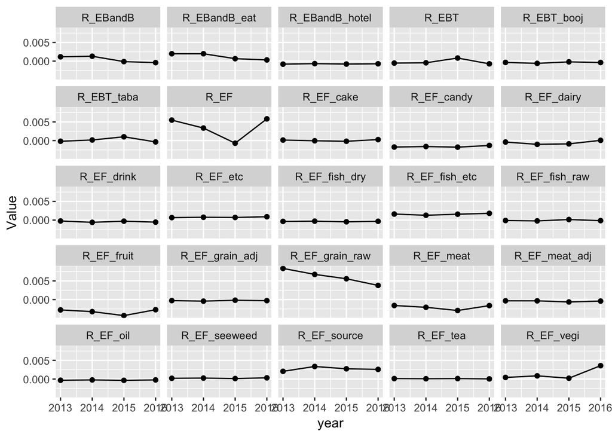

```r
Eshare[,c(1:2,260:371)] %>% group_by(year,quarter) %>% summarize_all(mean) %>% select(1:2,4:25,102:104) %>% mutate_at(-(1:2),dmean) %>% gather(Vname,Value,3:27) %>% filter(quarter==44) %>% ggplot(aes(x=year, y=Value))+geom_line()+geom_point()+facet_wrap(~Vname)
```

In fact, only 6 items had the largest 4th quater drop in consumption share compared to annual average in 2016. Among them, the drop of the value of ‘eateary and hotel’(R_EBandB) and ‘Taste’(R_EBT) represent the drop of the value of consumption share of eating out (R_BandB_eat) and the drop of the value of tabaco (R_EBT_taba) consumption. And the other two items are raw grain (R_EF_grain_raw) and tea (R_EF_tea). Raw_grain, tea, tabaco are not affected by ‘Clean Act’. So the only items matters is the drop of consumption share of eating out in 2016.

```r
Eshare[,c(1:2,260:371)] %>% group_by(year,quarter) %>% summarize_all(mean) %>% select(1:2,4:25,102:104) %>% mutate_at(-(1:2),dmean) %>% filter(quarter==44) %>% gather(Vname,Value,-(1:2)) %>% ungroup() %>% group_by(Vname) %>% summarize_at(-(1:2),which.min) %>%filter(Value==4)
```

```
## # A tibble: 6 × 2
##            Vname Value
##            <chr> <int>
## 1       R_EBandB     4
## 2   R_EBandB_eat     4
## 3          R_EBT     4
## 4     R_EBT_taba     4
## 5 R_EF_grain_raw     4
## 6       R_EF_tea     4
```

```r
Eshare[,c(1:2,260:371)] %>% group_by(year,quarter) %>% summarize_all(mean) %>% select(1:2,4:25,102:104) %>% mutate_at(-(1:2),dmean) %>% filter(quarter==44) %>% select(year,quarter,R_EBandB_eat)
```

```
## Source: local data frame [4 x 3]
## Groups: year [4]
##
##    year quarter R_EBandB_eat
##   <int>   <int>        <dbl>
## 1  2013      44 0.0019720169
## 2  2014      44 0.0019744234
## 3  2015      44 0.0006548780
## 4  2016      44 0.0003139053
```

```r
Eshare[,c(1:2,260:371)] %>% group_by(year,quarter) %>% summarize_all(mean) %>% select(1:2,4:25,102:104) %>% select(year,quarter,R_EBandB_eat)
```

```
## Source: local data frame [16 x 3]
## Groups: year [4]
##
##     year quarter R_EBandB_eat
##    <int>   <int>        <dbl>
## 1   2013      14    0.1127897
## 2   2013      24    0.1283029
## 3   2013      34    0.1263721
## 4   2013      44    0.1251176
## 5   2014      14    0.1138472
## 6   2014      24    0.1298535
## 7   2014      34    0.1301489
## 8   2014      44    0.1272491
## 9   2015      14    0.1169767
## 10  2015      24    0.1295819
## 11  2015      34    0.1293629
## 12  2015      44    0.1261803
## 13  2016      14    0.1180246
## 14  2016      24    0.1314126
## 15  2016      34    0.1284432
## 16  2016      44    0.1263787
```

```r
Eshare[,c(1:2,340,342)] %>% group_by(year, quarter) %>% summarize_all(mean) %>% mutate_at(-(1:2),dmean) %>% filter(quarter==44) %>% arrange(year) %>% gather(Vname,Value,-(1:2))
```

```
## Source: local data frame [8 x 4]
## Groups: year [4]
##
##    year quarter                Vname         Value
##   <int>   <int>                <chr>         <dbl>
## 1  2013      44        R_EENT_flower -1.330146e-03
## 2  2014      44        R_EENT_flower -1.221888e-03
## 3  2015      44        R_EENT_flower -1.038023e-03
## 4  2016      44        R_EENT_flower -1.099986e-03
## 5  2013      44 R_EENT_flowerpetserv -9.136058e-05
## 6  2014      44 R_EENT_flowerpetserv -7.402776e-06
## 7  2015      44 R_EENT_flowerpetserv  1.463806e-04
## 8  2016      44 R_EENT_flowerpetserv -1.482396e-04
```

```r
Eshare[,c(1:2,340,342)] %>% group_by(year, quarter) %>% summarize_all(mean) %>% filter(quarter==44) %>% gather(Vname,Value,-(1:2))
```

```
## Source: local data frame [8 x 4]
## Groups: year [4]
##
##    year quarter                Vname        Value
##   <int>   <int>                <chr>        <dbl>
## 1  2013      44        R_EENT_flower 0.0008715202
## 2  2014      44        R_EENT_flower 0.0007199947
## 3  2015      44        R_EENT_flower 0.0008968032
## 4  2016      44        R_EENT_flower 0.0008876865
## 5  2013      44 R_EENT_flowerpetserv 0.0005586875
## 6  2014      44 R_EENT_flowerpetserv 0.0005874239
## 7  2015      44 R_EENT_flowerpetserv 0.0008776545
## 8  2016      44 R_EENT_flowerpetserv 0.0006705847
```